# Duration models (I)

Wen Fan

2025-10-23

# Install and load R packages

First, load the necessary libraries and the data. For event history analysis, we’ll continue using the PSID data available [here](https://www.dropbox.com/scl/fi/sa44qdsocysjbz8h9sncs/psid.dta?rlkey=bwwfgglu41jbic6zfh6jev0ub&dl=0) to model transition to parents.

```r
require(tidyverse)
require(haven)
require(sjPlot)
require(survival)
require(broom)
require(survminer)
require(flexsurv)
```

```r
psid <- read_dta("/Users/wenfan/Library/CloudStorage/Dropbox/Longitudinal Data/psid.dta")

# Sample selection
psid <- psid |>
  mutate(across(c(female, region), as.factor)) |>
  filter(age >= 15 & age <= 45) # Focus on prime childbearing ages
```

# Creating survival objects

For survival analysis, we first need to create survival objects using the `Surv()` function from the `survival` package. The `time` argument in the `Surv()` function specifies the follow-up duration until the event or censoring occurs, while the `event` argument indicates whether the event occurred (1) or not (0). There are many ways to define the starting point of the “clock.” For example, it could start at age 15, at the age when the individual first entered the study, since birth, or from the time they entered a relationship, among others. Here, we simply use the age at transition or censoring as the time variable. In other words, the clock starts at age 0 for everyone.

Let’s use the `anykid` variable (i.e., having any minor children living at home) to construct an event indicator (1 = has any child, 0 = no child) and a time variable representing the age at first childbirth. This is not a perfect measure of the transition to parenthood, but it will work for demonstration purposes.

```r
surv_data <- psid |>
  arrange(id, year) |>
  group_by(id) |>
  mutate(
    # even indicator
    became_parent = case_when(
      is.na(anykid) | is.na(lag(anykid)) ~ NA_real_,
      anykid == 1 & lag(anykid) == 0 ~ 1,
      TRUE ~ 0),

    # ever experienced the event
    ever_became_parent = max(became_parent, na.rm = TRUE),

    # age when event happened
    age_at_transition = case_when(
      ever_became_parent == 1 ~ age[which(became_parent == 1)[1]],
      ever_became_parent == 0 ~ age[n()],  # Last observation's age
      TRUE ~ NA_real_
    ),

    # identify left-censoring cases (those who had children before entering the study)
    left_censored = if_else(anykid[1] == 1, 1, 0, missing = 0)
  ) |>
  slice(1) |> # Keep one row per person
  ungroup() |>
  select(id, ever_became_parent, age_at_transition, left_censored, female, region) |>
  drop_na(age_at_transition, ever_became_parent) |>
  filter(left_censored == 0) |> # Drop left-censored cases
  filter(age_at_transition >= 15) # Drop those with event before age 15 (likely outliers)
```

You can also specify censoring types in the `Surv()` function using the `type` argument. The default is right-censoring, which is what we need here. We have already removed left-censoring cases in the data preparation step. For the survival object, note that “+” indicates right-censoring, “?” indicates unknown event status, and “” indicates the event occurred.

```r
# Create survival object
surv_obj <- Surv(time = surv_data$age_at_transition, event = surv_data$ever_became_parent)
head(surv_obj)
```

```
## [1] 26  25  23  24  45+ 16
```

# Life table method

We can use `survfit` with `type = "fleming-harrington"`, which approximates the actuarial method.

```r
life_table <- survfit(surv_obj ~ 1, data = surv_data, type = "fleming-harrington")

# Display life table summary at specific times
summary(life_table, times = c(0, 15, 25, 30, 35, 40, 45))
```

```
## Call: survfit(formula = surv_obj ~ 1, data = surv_data, type = "fleming-harrington")
##
##  time n.risk n.event survival std.err lower 95% CI upper 95% CI
##     0   1870       0    1.000 0.00000        1.000        1.000
##    15   1870       0    1.000 0.00000        1.000        1.000
##    25   1559     324    0.826 0.00877        0.809        0.844
##    30   1028     402    0.596 0.01166        0.573        0.619
##    35    562     263    0.417 0.01240        0.393        0.442
##    40    321     114    0.315 0.01256        0.291        0.341
##    45    143      30    0.275 0.01305        0.250        0.302
```

# Kaplan-Meier estimation

We can estimate the Kaplan-Meier survival function using the `survfit()` function.

```r
# Fit Kaplan-Meier model
km <- survfit(surv_obj ~ 1, data = surv_data)

# Summary of KM estimates
summary(km)
```

```
## Call: survfit(formula = surv_obj ~ 1, data = surv_data)
##
##  time n.risk n.event survival  std.err lower 95% CI upper 95% CI
##    16   1870       1    0.999 0.000535        0.998        1.000
##    17   1869       3    0.998 0.001068        0.996        1.000
##    18   1866       8    0.994 0.001847        0.990        0.997
##    19   1858      12    0.987 0.002603        0.982        0.992
##    20   1845      30    0.971 0.003874        0.964        0.979
##    21   1814      38    0.951 0.005005        0.941        0.961
##    22   1764      49    0.924 0.006125        0.912        0.936
##    23   1706      51    0.897 0.007059        0.883        0.911
##    24   1634      60    0.864 0.007978        0.848        0.880
##    25   1559      72    0.824 0.008887        0.807        0.842
##    26   1466      74    0.782 0.009665        0.764        0.801
##    27   1368      71    0.742 0.010294        0.722        0.762
```

[output cut: 18 more lines]

```r
tidy(km)
```

```
## # A tibble: 30 × 8
##     time n.risk n.event n.censor estimate std.error conf.high conf.low
##    <dbl>  <dbl>   <dbl>    <dbl>    <dbl>     <dbl>     <dbl>    <dbl>
##  1    16   1870       1        0    0.999  0.000535     1        0.998
##  2    17   1869       3        0    0.998  0.00107      1.000    0.996
##  3    18   1866       8        0    0.994  0.00186      0.997    0.990
##  4    19   1858      12        1    0.987  0.00264      0.992    0.982
##  5    20   1845      30        1    0.971  0.00399      0.979    0.964
##  6    21   1814      38       12    0.951  0.00526      0.961    0.941
##  7    22   1764      49        9    0.924  0.00663      0.936    0.912
##  8    23   1706      51       21    0.897  0.00787      0.911    0.883
##  9    24   1634      60       15    0.864  0.00924      0.880    0.848
## 10    25   1559      72       21    0.824  0.0108       0.842    0.807
## # ℹ 20 more rows
```

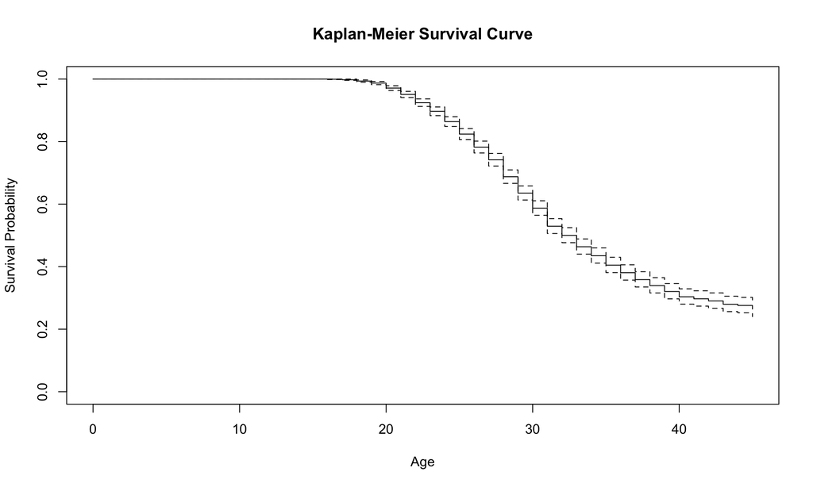

```r
# Plot Kaplan-Meier curve
plot(km, xlab = "Age", ylab = "Survival Probability", main = "Kaplan-Meier Survival Curve")
```

## Comparing groups using enhanced KM plot

We can use `gsurvplot` from the `survminer` package to create enhanced Kaplan-Meier plots with confidence intervals and risk tables.

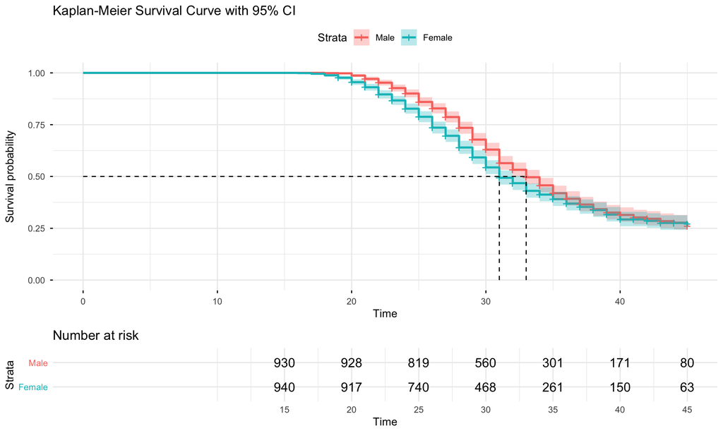

```r
km_gender <- survfit(surv_obj ~ female, data = surv_data)

ggsurvplot(km_gender,
           data = surv_data,
           risk.table = TRUE,
           conf.int = TRUE,
           surv.median.line = "hv", # Add horizontal and vertical lines at median survival
           legend.labs = c("Male", "Female"),
           ggtheme = theme_minimal(),
           title = "Kaplan-Meier Survival Curve with 95% CI")
```

# Log-rank test and Wilcoxon test

We can use log-rank test to compare survival curves between groups such as by region.

```r
survdiff(surv_obj ~ region, data = surv_data)
```

```
## Call:
## survdiff(formula = surv_obj ~ region, data = surv_data)
##
##            N Observed Expected (O-E)^2/E (O-E)^2/V
## region=1 306      177    204.3      3.64      4.70
## region=2 710      449    428.2      1.01      1.72
## region=3 547      337    298.2      5.06      7.27
## region=4 290      162    190.6      4.30      5.48
## region=5  17        8     11.7      1.19      1.28
##
##  Chisq= 16.1  on 4 degrees of freedom, p= 0.003
```

We can also conduct Wilcoxon test by specifying the `rho` parameter in the `survdiff()` function.

```r
# Wilcoxon (Breslow) test
survdiff(surv_obj ~ region, data = surv_data, rho = 1)
```

```
## Call:
## survdiff(formula = surv_obj ~ region, data = surv_data, rho = 1)
##
##            N Observed Expected (O-E)^2/E (O-E)^2/V
## region=1 306   112.29    139.2     5.213     8.973
## region=2 710   308.88    297.5     0.435     0.983
## region=3 547   243.25    208.6     5.744    10.906
## region=4 290   112.10    127.8     1.921     3.288
## region=5  17     4.92      8.3     1.377     1.956
##
##  Chisq= 20.7  on 4 degrees of freedom, p= 4e-04
```

# Median survival time

We can estimate the median survival time using the `surv_median()` function from the `survminer` package.

```r
median_surv <- surv_median(km)
median_surv
```

```
##   strata median lower upper
## 1    All     33    32    33
```

```r
# By group
median_surv_gender <- surv_median(km_gender)
median_surv_gender
```

```
##     strata median lower upper
## 1 female=0     33    32    34
## 2 female=1     31    31    33
```

# Parametric survival models

For parametric survival models, we can use the `survreg()` function from the `survival` package or the `flexsurvreg()` function from the `flexsurv` package. The two functions differ slightly in syntax and functionality, with `flexsurvreg()` offering support for a broader range of distributions. Here, we will fit several common parametric models: exponential, Weibull, log-normal, log-logistic, and Gompertz.

## Exponential model

Note that `survreg()` uses the AFT (accelerated failure time) parameterization, which models survival times. In contrast, `flexsurvreg()` models the hazard rate in the case of exponential models.

```r
exp_fit <- survreg(surv_obj ~ female + region, data = surv_data, dist = "exponential")
summary(exp_fit)
```

```
##
## Call:
## survreg(formula = surv_obj ~ female + region, data = surv_data,
##     dist = "exponential")
##               Value Std. Error     z      p
## (Intercept)  4.0520     0.0809 50.11 <2e-16
## female1     -0.0401     0.0595 -0.67   0.50
## region2     -0.1251     0.0888 -1.41   0.16
## region3     -0.1311     0.0928 -1.41   0.16
## region4      0.0242     0.1087  0.22   0.82
## region5      0.1874     0.3618  0.52   0.60
##
## Scale fixed at 1
##
## Exponential distribution
## Loglik(model)= -5606.2   Loglik(intercept only)= -5609.1
##  Chisq= 5.88 on 5 degrees of freedom, p= 0.32
## Number of Newton-Raphson Iterations: 3
## n= 1870
```

```r
# Alternatively, using flexsurv package
exp_flex <- flexsurvreg(surv_obj ~ female + region, data = surv_data, dist = "exponential")
exp_flex
```

```
## Call:
## flexsurvreg(formula = surv_obj ~ female + region, data = surv_data,
##     dist = "exponential")
##
## Estimates:
##          data mean  est       L95%      U95%      se        exp(est)  L95%
## rate           NA    0.01739   0.01484   0.02037   0.00141        NA        NA
## female1   0.50267    0.04010  -0.07649   0.15669   0.05949   1.04092   0.92636
## region2   0.37968    0.12507  -0.04888   0.29902   0.08875   1.13323   0.95229
## region3   0.29251    0.13107  -0.05087   0.31301   0.09283   1.14005   0.95041
## region4   0.15508   -0.02424  -0.23735   0.18888   0.10873   0.97606   0.78872
## region5   0.00909   -0.18739  -0.89656   0.52178   0.36183   0.82912   0.40797
##          U95%
## rate           NA
## female1   1.16964
## region2   1.34854
## region3   1.36754
## region4   1.20789
## region5   1.68502
##
## N = 1870,  Events: 1133,  Censored: 737
## Total time at risk: 58884
## Log-likelihood = -5606.204, df = 6
## AIC = 11224.41
```

## Weibull model

For Weibull models, both `survreg()` and `flexsurvreg()` use the AFT parameterization. The “shape” parameter in the Weibull distribution indicates whether the hazard is increasing (shape $> 1$), decreasing (shape $< 1$), or constant (shape $= 1$, which reduces to the exponential model) over time.

```r
weib_fit <- survreg(surv_obj ~ female + region, data = surv_data, dist = "weibull")
summary(weib_fit)
```

```
##
## Call:
## survreg(formula = surv_obj ~ female + region, data = surv_data,
##     dist = "weibull")
##                Value Std. Error      z      p
## (Intercept)  3.70278    0.02094 176.80 <2e-16
## female1     -0.03108    0.01535  -2.02 0.0429
## region2     -0.05434    0.02290  -2.37 0.0177
## region3     -0.06963    0.02396  -2.91 0.0037
## region4      0.00983    0.02804   0.35 0.7258
## region5     -0.00411    0.09336  -0.04 0.9649
## Log(scale)  -1.35522    0.02357 -57.49 <2e-16
##
## Scale= 0.258
##
## Weibull distribution
## Loglik(model)= -4706.3   Loglik(intercept only)= -4716.7
##  Chisq= 20.93 on 5 degrees of freedom, p= 0.00084
## Number of Newton-Raphson Iterations: 5
## n= 1870
```

```r
# Alternatively, using flexsurv package
weib_flex <- flexsurvreg(surv_obj ~ female + region, data = surv_data, dist = "weibull")
weib_flex
```

```
## Call:
## flexsurvreg(formula = surv_obj ~ female + region, data = surv_data,
##     dist = "weibull")
##
## Estimates:
##          data mean  est        L95%       U95%       se         exp(est)
## shape           NA   3.877603   3.702511   4.060976   0.091414         NA
## scale           NA  40.559978  38.928741  42.259570   0.849478         NA
## female1   0.502674  -0.031080  -0.061165  -0.000995   0.015350   0.969398
## region2   0.379679  -0.054337  -0.099219  -0.009455   0.022900   0.947113
## region3   0.292513  -0.069628  -0.116581  -0.022676   0.023956   0.932740
## region4   0.155080   0.009833  -0.045127   0.064794   0.028042   1.009882
## region5   0.009091  -0.004113  -0.187101   0.178875   0.093363   0.995895
##          L95%       U95%
## shape           NA         NA
## scale           NA         NA
## female1   0.940668   0.999005
## region2   0.905544   0.990590
## region3   0.889958   0.977579
## region4   0.955876   1.066939
## region5   0.829360   1.195871
##
## N = 1870,  Events: 1133,  Censored: 737
## Total time at risk: 58884
## Log-likelihood = -4706.282, df = 7
## AIC = 9426.563
```

## Gompertz model

Gompertz models are not available in `survreg()`, but can be fitted using `flexsurvreg()`, which models the hazard rate. The shape parameter indicates whether the hazard is increasing (shape $> 0$) or decreasing (shape $< 0$) over time.

```r
gomp_flex <- flexsurvreg(surv_obj ~ female + region, data = surv_data, dist = "gompertz")
gomp_flex
```

```
## Call:
## flexsurvreg(formula = surv_obj ~ female + region, data = surv_data,
##     dist = "gompertz")
##
## Estimates:
##          data mean  est       L95%      U95%      se        exp(est)  L95%
## shape          NA    0.10763   0.10188   0.11338   0.00293        NA        NA
## rate           NA    0.00134   0.00106   0.00170   0.00016        NA        NA
## female1   0.50267    0.11184  -0.00483   0.22852   0.05953   1.11834   0.99518
## region2   0.37968    0.20912   0.03508   0.38315   0.08880   1.23259   1.03570
## region3   0.29251    0.25922   0.07715   0.44129   0.09289   1.29592   1.08021
## region4   0.15508   -0.04076  -0.25388   0.17237   0.10874   0.96006   0.77578
## region5   0.00909    0.06248  -0.64762   0.77258   0.36230   1.06447   0.52329
##          U95%
## shape          NA
## rate           NA
## female1   1.25673
## region2   1.46690
## region3   1.55471
## region4   1.18811
## region5   2.16534
##
## N = 1870,  Events: 1133,  Censored: 737
## Total time at risk: 58884
## Log-likelihood = -4858.466, df = 7
## AIC = 9730.933
```

## Log-normal model

```r
logn_fit <- survreg(surv_obj ~ female + region, data = surv_data, dist = "lognormal")
summary(logn_fit)
```

```
##
## Call:
## survreg(formula = surv_obj ~ female + region, data = surv_data,
##     dist = "lognormal")
##               Value Std. Error      z       p
## (Intercept)  3.6010     0.0203 177.51 < 2e-16
## female1     -0.0532     0.0149  -3.57 0.00036
## region2     -0.0607     0.0222  -2.73 0.00632
## region3     -0.0882     0.0232  -3.80 0.00015
## region4     -0.0226     0.0267  -0.85 0.39746
## region5      0.0278     0.0847   0.33 0.74256
## Log(scale)  -1.2124     0.0222 -54.56 < 2e-16
##
## Scale= 0.297
##
## Log Normal distribution
## Loglik(model)= -4557.7   Loglik(intercept only)= -4573.3
##  Chisq= 31.13 on 5 degrees of freedom, p= 8.8e-06
## Number of Newton-Raphson Iterations: 3
## n= 1870
```

```r
# Alternatively, using flexsurv package
logn_flex <- flexsurvreg(surv_obj ~ female + region, data = surv_data, dist = "lognormal")
logn_flex
```

```
## Call:
## flexsurvreg(formula = surv_obj ~ female + region, data = surv_data,
##     dist = "lognormal")
##
## Estimates:
##          data mean  est       L95%      U95%      se        exp(est)  L95%
## meanlog        NA    3.60102   3.56126   3.64078   0.02029        NA        NA
## sdlog          NA    0.29749   0.28481   0.31073   0.00661        NA        NA
## female1   0.50267   -0.05324  -0.08251  -0.02397   0.01493   0.94815   0.92080
## region2   0.37968   -0.06067  -0.10423  -0.01712   0.02222   0.94113   0.90102
## region3   0.29251   -0.08823  -0.13375  -0.04271   0.02322   0.91555   0.87481
## region4   0.15508   -0.02261  -0.07497   0.02976   0.02672   0.97765   0.92777
## region5   0.00909    0.02783  -0.13826   0.19393   0.08474   1.02823   0.87087
##          U95%
## meanlog        NA
## sdlog          NA
## female1   0.97631
## region2   0.98302
## region3   0.95819
## region4   1.03021
## region5   1.21401
##
## N = 1870,  Events: 1133,  Censored: 737
## Total time at risk: 58884
## Log-likelihood = -4557.713, df = 7
## AIC = 9129.425
```

## Log-logistic model

```r
logl_fit <- survreg(surv_obj ~ female + region, data = surv_data,dist = "loglogistic")
summary(logl_fit)
```

```
##
## Call:
## survreg(formula = surv_obj ~ female + region, data = surv_data,
##     dist = "loglogistic")
##                Value Std. Error      z       p
## (Intercept)  3.58740    0.02042 175.70 < 2e-16
## female1     -0.05236    0.01521  -3.44 0.00058
## region2     -0.06465    0.02243  -2.88 0.00394
## region3     -0.09253    0.02356  -3.93 8.6e-05
## region4     -0.00959    0.02775  -0.35 0.72967
## region5      0.02824    0.08190   0.34 0.73020
## Log(scale)  -1.73146    0.02448 -70.72 < 2e-16
##
## Scale= 0.177
##
## Log logistic distribution
## Loglik(model)= -4583.4   Loglik(intercept only)= -4600.5
##  Chisq= 34.17 on 5 degrees of freedom, p= 2.2e-06
## Number of Newton-Raphson Iterations: 3
## n= 1870
```

```r
# Alternatively, using flexsurv package
logl_flex <- flexsurvreg(surv_obj ~ female + region, data = surv_data, dist = "llogis")
logl_flex
```

```
## Call:
## flexsurvreg(formula = surv_obj ~ female + region, data = surv_data,
##     dist = "llogis")
##
## Estimates:
##          data mean  est       L95%      U95%      se        exp(est)  L95%
## shape          NA    5.64890   5.38423   5.92657   0.13830        NA        NA
## scale          NA   36.13991  34.72223  37.61547   0.73789        NA        NA
## female1   0.50267   -0.05236  -0.08218  -0.02254   0.01521   0.94899   0.92111
## region2   0.37968   -0.06465  -0.10860  -0.02069   0.02243   0.93740   0.89709
## region3   0.29251   -0.09253  -0.13871  -0.04635   0.02356   0.91162   0.87048
## region4   0.15508   -0.00959  -0.06397   0.04479   0.02775   0.99046   0.93803
## region5   0.00909    0.02824  -0.13227   0.18876   0.08190   1.02865   0.87610
##          U95%
## shape          NA
## scale          NA
## female1   0.97771
## region2   0.97952
## region3   0.95471
## region4   1.04581
## region5   1.20775
##
## N = 1870,  Events: 1133,  Censored: 737
## Total time at risk: 58884
## Log-likelihood = -4583.391, df = 7
## AIC = 9180.782
```

## Model comparison

```r
# Extract AIC values
models <- list(
  Exponential = exp_flex,
  Weibull = weib_flex,
  LogNormal = logn_flex,
  LogLogistic = logl_flex,
  Gompertz = gomp_flex
)

# Compare BICs
bic_values <- sapply(models, BIC)
print(bic_values)
```

```
## Exponential     Weibull   LogNormal LogLogistic    Gompertz
##   11257.610    9465.299    9168.161    9219.518    9769.669
```

```r
# Likelihood ratio test for nested models (exponential vs Weibull, as exponential is nested within Weibull)
lr_test <- 2 * (logLik(weib_fit) - logLik(exp_fit))
p_value <- pchisq(lr_test, df = 1, lower.tail = FALSE)
cat("LR test statistic:", lr_test, "\n")
```

```
## LR test statistic: 1799.844
```

```r
cat("p-value:", p_value, "\n")
```

```
## p-value: 0
```

## Predicted survival times

We can obtain predicted survival times (e.g., median or mean survival times) from the fitted parametric models.

```r
# Get predicted median survival times from log-normal model
pred_median <- predict(logn_fit, type = "quantile", p = 0.5)
head(pred_median)
```

```
## [1] 34.47869 32.69096 33.54155 31.80242 31.80242 31.80242
```

```r
# Create new data for prediction
new_data <- data.frame(
  female = factor(c(0, 0, 0, 0, 0, 1, 1, 1, 1, 1)),
  region = factor(c(1, 2, 3, 4, 5, 1, 2, 3, 4, 5))
)

# Predict for new data
pred_new <- predict(logn_fit, newdata = new_data, type = "quantile", p = 0.5)
print(pred_new)
```

```
##        1        2        3        4        5        6        7        8
## 36.63543 34.47869 33.54155 35.81646 37.66949 34.73587 32.69096 31.80242
##        9       10
## 33.95937 35.71632
```

## Plotting parametric survival curves

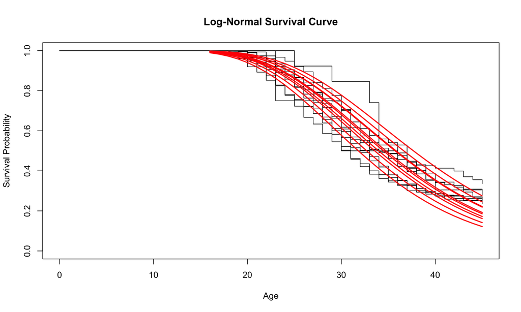

```r
# Plot survival and hazard curves for different models
plot(logn_flex, type = "survival",
     xlab = "Age",
     ylab = "Survival Probability",
     main = "Log-Normal Survival Curve")
```

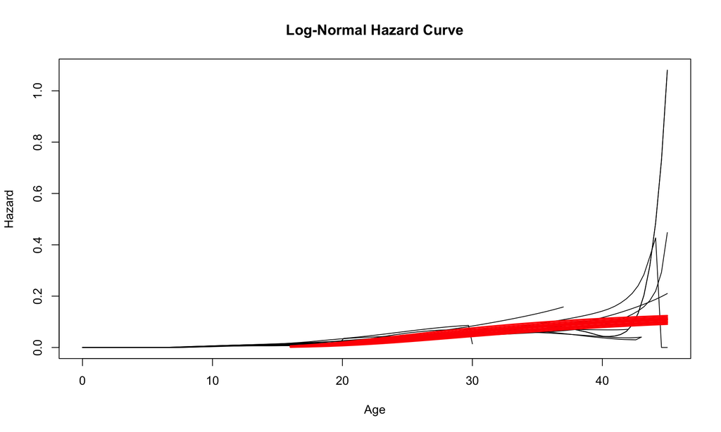

```r
plot(logn_flex, type = "hazard",
     xlab = "Age",
     ylab = "Hazard",
     main = "Log-Normal Hazard Curve")
```

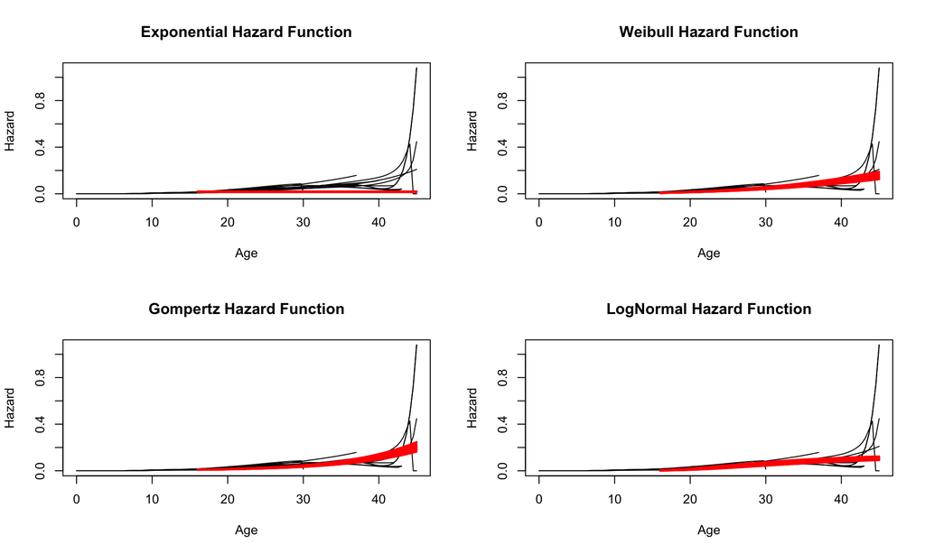

```r
# Compare different parametric models
models_flex <- list(
  Exponential = exp_flex,
  Weibull = weib_flex,
  Gompertz = gomp_flex,
  LogNormal = logn_flex
)

# Create comparison plot
par(mfrow = c(2, 2))
for(i in 1:4) {
  plot(models_flex[[i]], type = "hazard",
       xlab = "Age",
       ylab = "Hazard",
       main = paste(names(models_flex)[i], "Hazard Function"))
}
```

```r
par(mfrow = c(1, 1))
```